# Statistical Inference Project 1: Part2 Basic Inferential Data Analysis

Frank Minjarez

3/13/2017

Code Here: https://github.com/frankminjarez/StatisticalInference.git

Now in the second portion of the project, we’re going to analyze the ToothGrowth data in the R datasets package.

1. Load the ToothGrowth data and perform some basic exploratory data analyses
2. Provide a basic summary of the data.
3. Use confidence intervals and/or hypothesis tests to compare tooth growth by supp and dose. (Only use the techniques from class, even if there’s other approaches worth considering)
4. State your conclusions and the assumptions needed for your conclusions.

## 1. Load the ToothGrowth data and perform some basic exploratory data analyses

```r
library(datasets)
data(ToothGrowth)
head(ToothGrowth)
```

```
##    len supp dose
## 1  4.2   VC  0.5
## 2 11.5   VC  0.5
## 3  7.3   VC  0.5
## 4  5.8   VC  0.5
## 5  6.4   VC  0.5
## 6 10.0   VC  0.5
```

### The population of the dataset appears to have a normal distribution

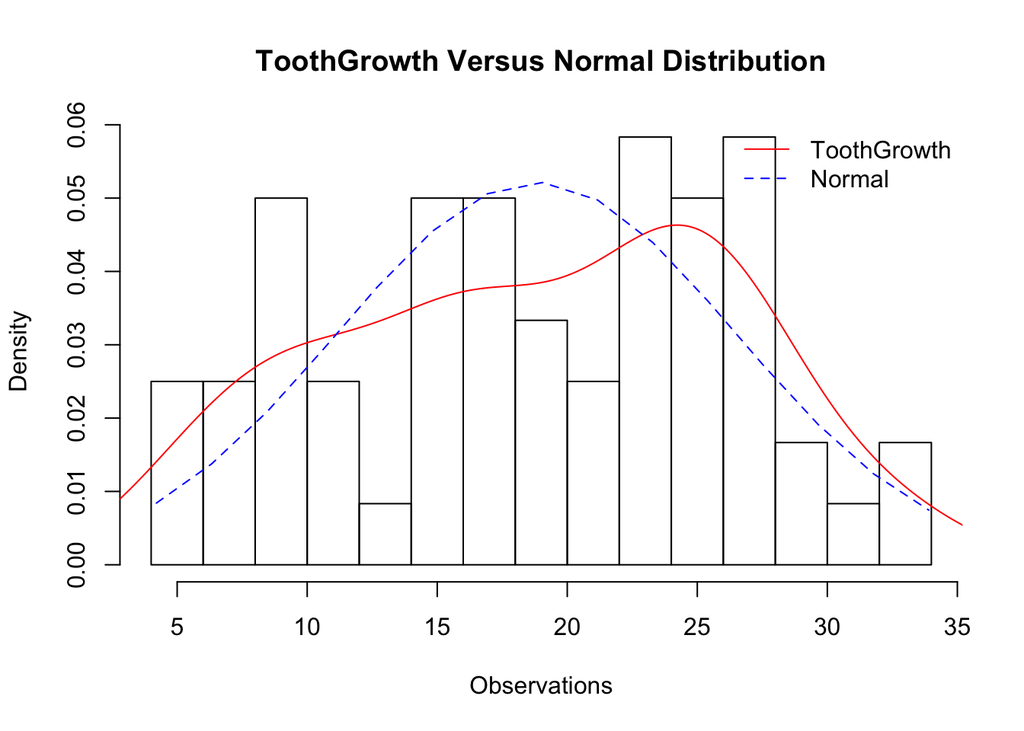

```r
hist(ToothGrowth$len,
     breaks = 15,
     prob = TRUE,
     main = "ToothGrowth Versus Normal Distribution",
     xlab = "Observations")

## Sample density
lines(density(ToothGrowth$len), col="red")

## Theoretical normal density
xnorm <- seq(min(ToothGrowth$len), max(ToothGrowth$len), length = 15)
ynorm <- dnorm(xnorm, mean = mean(ToothGrowth$len), sd = sd(ToothGrowth$len))
lines(xnorm, ynorm, pch = 22, col = "blue", lty = 2)

legend("topright", c("ToothGrowth", "Normal"),
       bty = "n", lty = c(1,2), col = c("red", "blue"))
```

```r
str(ToothGrowth)
```

```
## 'data.frame':    60 obs. of  3 variables:
##  $ len : num  4.2 11.5 7.3 5.8 6.4 10 11.2 11.2 5.2 7 ...
##  $ supp: Factor w/ 2 levels "OJ","VC": 2 2 2 2 2 2 2 2 2 2 ...
##  $ dose: num  0.5 0.5 0.5 0.5 0.5 0.5 0.5 0.5 0.5 0.5 ...
```

## 2. Provide a basic summary of the data

```r
library(ggplot2)
ToothGrowth$dose <- as.factor(ToothGrowth$dose)
table(ToothGrowth$supp, ToothGrowth$dose)
```

```
##
##      0.5  1  2
##   OJ  10 10 10
##   VC  10 10 10
```

```r
summary(ToothGrowth)
```

```
##       len        supp     dose
##  Min.   : 4.20   OJ:30   0.5:20
##  1st Qu.:13.07   VC:30   1  :20
##  Median :19.25           2  :20
##  Mean   :18.81
##  3rd Qu.:25.27
##  Max.   :33.90
```

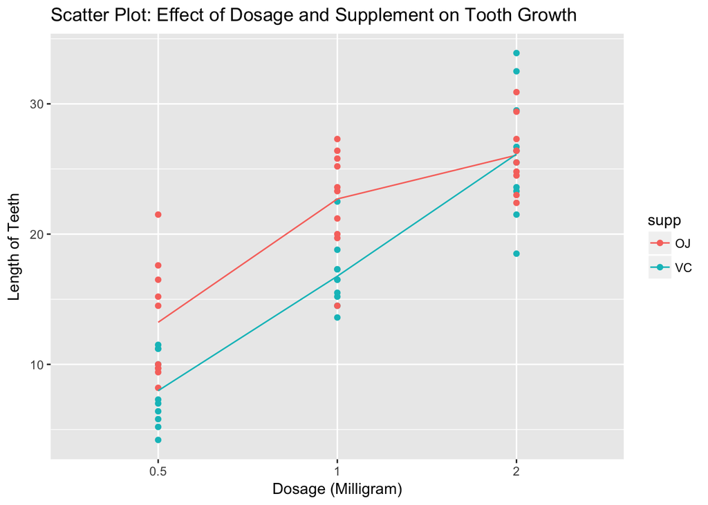

```r
# Caclulate mean tooth len
meanToothLen <- aggregate(len~.,data=ToothGrowth,mean)
# Scatter plot and the avg lines for the average length
g <- ggplot(ToothGrowth,aes(x=dose,y=len))
g <- g + geom_point(aes(group=supp, colour=supp))
g <- g + scale_x_discrete("Dosage (Milligram)")
g <- g + scale_y_continuous("Length of Teeth")
g <- g + geom_line(data=meanToothLen,aes(group=supp,colour=supp))
g + ggtitle("Scatter Plot: Effect of Dosage and Supplement on Tooth Growth")
```

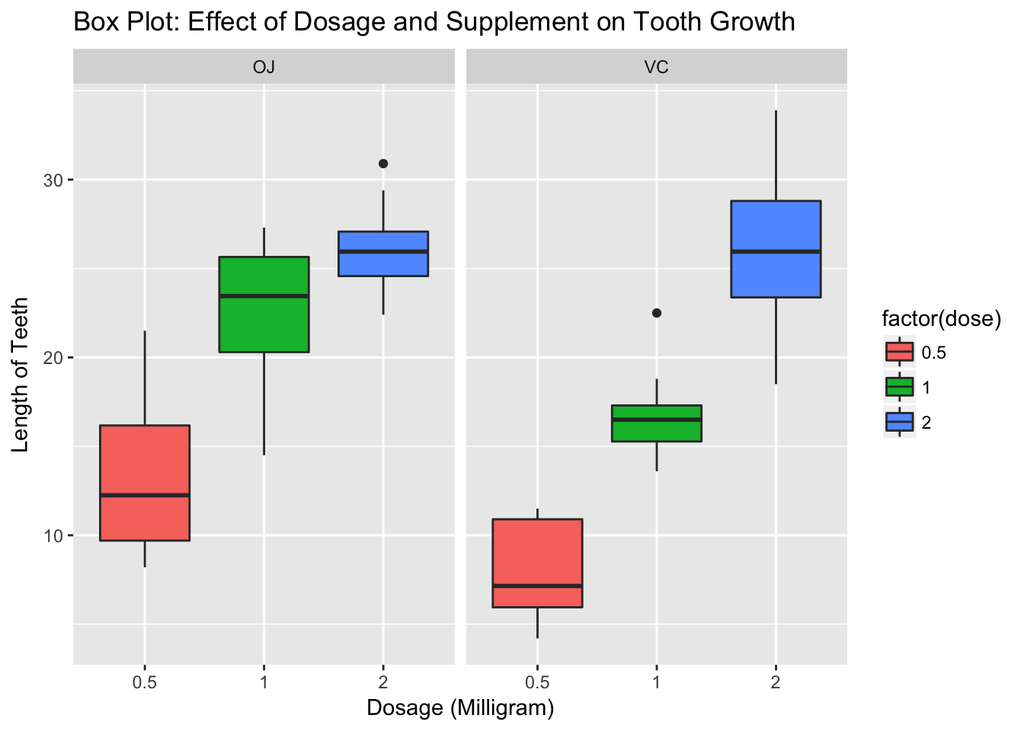

```r
g <- ggplot(ToothGrowth, aes(x=factor(dose),y=len, fill=factor(dose)))
g <- g + geom_boxplot(notch=F) + facet_grid(.~supp)
g <- g + scale_x_discrete("Dosage (Milligram)")
g <- g + scale_y_continuous("Length of Teeth")
g + ggtitle("Box Plot: Effect of Dosage and Supplement on Tooth Growth")
```

## 3. Use confidence intervals and/or hypothesis tests to compare tooth growth by supp and dose

### Low p-value and higher mean len. OJ is more effective at 0.5 dosage.

```r
n <- subset(ToothGrowth, dose == 0.5)
t.test(len~supp, paired=F, var.equal=T, data=n)
```

```
##
##  Two Sample t-test
##
## data:  len by supp
## t = 3.1697, df = 18, p-value = 0.005304
## alternative hypothesis: true difference in means is not equal to 0
## 95 percent confidence interval:
##  1.770262 8.729738
## sample estimates:
## mean in group OJ mean in group VC
##            13.23             7.98
```

### Low p-value and higher mean len. OJ is more effective at 1 dosage.

```r
n <- subset(ToothGrowth, dose == 1)
t.test(len~supp, paired=F, var.equal=T, data=n)
```

```
##
##  Two Sample t-test
##
## data:  len by supp
## t = 4.0328, df = 18, p-value = 0.0007807
## alternative hypothesis: true difference in means is not equal to 0
## 95 percent confidence interval:
##  2.840692 9.019308
## sample estimates:
## mean in group OJ mean in group VC
##            22.70            16.77
```

### High p-value and equal mean len. OJ and VC have the same effect at 2 dosage.

```r
n <- subset(ToothGrowth, dose == 2)
t.test(len~supp, paired=F, var.equal=T, data=n)
```

```
##
##  Two Sample t-test
##
## data:  len by supp
## t = -0.046136, df = 18, p-value = 0.9637
## alternative hypothesis: true difference in means is not equal to 0
## 95 percent confidence interval:
##  -3.722999  3.562999
## sample estimates:
## mean in group OJ mean in group VC
##            26.06            26.14
```

## 4. State your conclusions and the assumptions needed for your conclusions

Our early exploratory data analysis indicated the population has a normal distribution so we are assuming that we can use the t-interval test with our small sample set.

1. Both the scatter plot and the box plot indicate that as the dosage increases the effectiveness of the both the methods increases.
2. Hypothesis and confidence t-interval analysis indicate that for 0.5 and 1.0 dose values OJ is a more effective method. For dosage values of 2.0 both supplements achieve are the same results.